# Loading Dataset into Jupyter notebook

```python
#importing libraries necessary for the exercise

import pandas as pd
import numpy as np
import matplotlib.pyplot as plt
import seaborn as sns
```

```python
df_horse = pd.read_csv('Horses.csv') #loading dataset into a dataframe
```

# EXPLORATORY DATA ANALYSIS

```python
df_horse.head() #revealing the first then records
```

|  | RaceID | HorseID | Cloth | Stall | WeightValue | JockeyID | AllowanceValue | OverweightValue | TrainerID | OwnerID | ... | Going | Weather | Course_Distance | RaceType | TrackType | Handicap | eligibility | CourseID | MeetingDate | Won |
| --- | --- | --- | --- | --- | --- | --- | --- | --- | --- | --- | --- | --- | --- | --- | --- | --- | --- | --- | --- | --- | --- |
| 0 | 989418 | 2963489 | 7 | 5.0 | 132 | 1398052.0 | NaN | NaN | 1198534 | 1289143.0 | ... | Good | Cloudy | 1312 | Flat | Turf | NaN | 2YO only | 380 | 02/05/2017 | 0 |
| 1 | 989418 | 2972665 | 13 | 6.0 | 132 | 1165412.0 | NaN | NaN | 1188128 | 1140080.0 | ... | Good | Cloudy | 1312 | Flat | Turf | NaN | 2YO only | 380 | 02/05/2017 | 0 |
| 2 | 989418 | 2972662 | 9 | 7.0 | 132 | 1239852.0 | NaN | NaN | 1199122 | 1448576.0 | ... | Good | Cloudy | 1312 | Flat | Turf | NaN | 2YO only | 380 | 02/05/2017 | 0 |
| 3 | 989418 | 2960365 | 1 | 12.0 | 132 | 1417524.0 | NaN | NaN | 1049637 | 1487690.0 | ... | Good | Cloudy | 1312 | Flat | Turf | NaN | 2YO only | 380 | 02/05/2017 | 1 |
| 4 | 989418 | 2968596 | 11 | 8.0 | 132 | 1354773.0 | NaN | NaN | 1140041 | 1403676.0 | ... | Good | Cloudy | 1312 | Flat | Turf | NaN | 2YO only | 380 | 02/05/2017 | 0 |

5 rows × 46 columns

```python
#some columns are truncated and will require full view to see full data

pd.set_option('display.max_columns', None)
df_horse.head() #first 10 rows of the untruncated data
```

|  | RaceID | HorseID | Cloth | Stall | WeightValue | JockeyID | AllowanceValue | OverweightValue | TrainerID | OwnerID | LastRunDaysFlat | Age | Blinkers | Hood | Visor | EyeShield | Eyecover | TongueStrap | CheekPieces | ForecastPrice | StatCourse | StatDistance | StatCourseDistance | StartingPrice | Bred | DamID | SireID | DamSireID | Sex | … |
| --- | --- | --- | --- | --- | --- | --- | --- | --- | --- | --- | --- | --- | --- | --- | --- | --- | --- | --- | --- | --- | --- | --- | --- | --- | --- | --- | --- | --- | --- | --- |
| 0 | 989418 | 2963489 | 7 | 5.0 | 132 | 1398052.0 | NaN | NaN | 1198534 | 1289143.0 | 26.0 | 3.0 | NaN | NaN | NaN | NaN | NaN | NaN | NaN | 16-Jan | NaN | NaN | NaN | 12-Jan | SAF | 2803520.0 | 2004880.0 | 2179351.0 | f | … |
| 1 | 989418 | 2972665 | 13 | 6.0 | 132 | 1165412.0 | NaN | NaN | 1188128 | 1140080.0 | NaN | 3.0 | NaN | NaN | NaN | NaN | NaN | NaN | NaN | 20-Jan | NaN | NaN | NaN | 40/1 | SAF | 2749301.0 | 2960049.0 | 2001540.0 | f | … |
| 2 | 989418 | 2972662 | 9 | 7.0 | 132 | 1239852.0 | NaN | NaN | 1199122 | 1448576.0 | NaN | 3.0 | NaN | NaN | NaN | NaN | NaN | NaN | NaN | 10-Jan | NaN | NaN | NaN | NaN | SAF | 2761722.0 | 2441786.0 | 2123459.0 | f | … |
| 3 | 989418 | 2960365 | 1 | 12.0 | 132 | 1417524.0 | NaN | NaN | 1049637 | 1487690.0 | 33.0 | 3.0 | NaN | NaN | NaN | NaN | NaN | NaN | NaN | 07-Apr | NaN | NaN | NaN | 11-Oct | SAF | 2347111.0 | 2170013.0 | 2071137.0 | f | … |
| 4 | 989418 | 2968596 | 11 | 8.0 | 132 | 1354773.0 | NaN | NaN | 1140041 | 1403676.0 | 24.0 | 3.0 | NaN | NaN | NaN | NaN | NaN | NaN | NaN | 08-Jan | NaN | NaN | NaN | NaN | SAF | 2618721.0 | 2410998.0 | 2170115.0 | f | … |

# Quick observations

- Startingprice, ForecastPrice contain date inputs
- ScheduleTime contains invalid inputs ####

# Initial explorations

```python
df_horse.info()   # This gives us understanding of the dataset to see number of records, datatypes, non-null values count
```

```
<class 'pandas.core.frame.DataFrame'>
RangeIndex: 36819 entries, 0 to 36818
Data columns (total 46 columns):
 #   Column              Non-Null Count  Dtype
---  ------              --------------  -----
 0   RaceID              36819 non-null  int64
 1   HorseID             36819 non-null  int64
 2   Cloth               36819 non-null  int64
 3   Stall               36615 non-null  float64
 4   WeightValue         36819 non-null  int64
 5   JockeyID            36818 non-null  float64
 6   AllowanceValue      1609 non-null   float64
 7   OverweightValue     106 non-null    float64
 8   TrainerID           36819 non-null  int64
 9   OwnerID             36616 non-null  float64
```

[output cut: 38 more lines]

```python
df_horse.isnull().sum() #This displays the dataset and the sum total of the null values by column.
```

```
RaceID                    0
HorseID                   0
Cloth                     0
Stall                   204
WeightValue               0
JockeyID                  1
AllowanceValue        35210
OverweightValue       36713
TrainerID                 0
OwnerID                 203
LastRunDaysFlat        2519
Age                     203
Blinkers              26477
Hood                  36819
Visor                 36751
EyeShield             36819
Eyecover              36819
TongueStrap           36819
CheekPieces           36819
ForecastPrice          1727
StatCourse            27987
StatDistance          29691
StatCourseDistance    29363
StartingPrice          4810
Bred                      0
DamID                     5
SireID                    5
DamSireID                 5
Sex                       5
Colour                    5
YearBorn              31659
MeetingID                 0
RaceNumber                0
ScheduledTime             0
HorseCount                0
Runners                  20
Going                   378
Weather                 378
Course_Distance           0
RaceType                 51
TrackType                51
Handicap              19413
eligibility              51
CourseID                  0
MeetingDate               0
Won                       0
dtype: int64
```

# Secondary Observations

From the dataset above, we can observe a few problems already

- The columns Hood, Eyeshield,Eyecover,TongueStrap and CheekPiece are completely null with no values and may need to be dropped.
- OverweightValue, Visor have very significant null values
- Meeting date has got the wrong data type(object instead of datetime), StartingPrice and ForecastValue(object instead of float)

# Questions

1. Why are there so many null values and empty columns?
2. Could it be that the data has not been properly warehoused or enteries not done by a Data analyst who understands the implications of the errors?

```python
df_horse.describe()  #statistics for numerical columns
```

|  | RaceID | HorseID | Cloth | Stall | WeightValue | JockeyID | AllowanceValue | OverweightValue | TrainerID | OwnerID | LastRunDaysFlat | Age | Blinkers | Hood | Visor | EyeShield | Eyecover | TongueStrap | CheekPieces | StatCourse | StatDistance | StatCourseDistance | DamID | SireID | DamSireID | YearBorn | MeetingID | RaceNumber | HorseCount | … |
| --- | --- | --- | --- | --- | --- | --- | --- | --- | --- | --- | --- | --- | --- | --- | --- | --- | --- | --- | --- | --- | --- | --- | --- | --- | --- | --- | --- | --- | --- | --- |
| count | 3.681900e+04 | 3.681900e+04 | 36819.000000 | 36615.000000 | 36819.000000 | 3.681800e+04 | 1609.000000 | 106.000000 | 3.681900e+04 | 3.661600e+04 | 34300.000000 | 36616.000000 | 10342.000000 | 0.0 | 68.000000 | 0.0 | 0.0 | 0.0 | 0.0 | 8832.000000 | 7128.000000 | 7456.000000 | 3.681400e+04 | 3.681400e+04 | 3.681400e+04 | 5160.000000 | 36819.000000 | 36819.000000 | 36819.000000 | … |
| mean | 1.009771e+06 | 2.929157e+06 | 7.052446 | 7.053093 | 126.604389 | 1.259822e+06 | 5.702921 | 1.320755 | 1.222769e+06 | 1.384368e+06 | 37.663848 | 4.268598 | 11.968768 | NaN | 5.250000 | NaN | NaN | NaN | NaN | 1.614357 | 1.494669 | 1.464995 | 2.637135e+06 | 2.404120e+06 | 2.143072e+06 | 2010.779070 | 89455.046878 | 5.018387 | 13.048236 | … |
| std | 1.144299e+04 | 5.846940e+04 | 4.208096 | 4.207354 | 6.066849 | 1.340399e+05 | 2.416773 | 0.834348 | 1.257340e+05 | 1.238528e+05 | 44.267732 | 1.220801 | 12.297527 | NaN | 4.409539 | NaN | NaN | NaN | NaN | 1.043961 | 0.916141 | 0.815910 | 1.805871e+05 | 2.584497e+05 | 1.539233e+05 | 0.970004 | 1328.259877 | 2.643495 | 3.351323 | … |
| min | 9.894180e+05 | 2.261982e+06 | 1.000000 | 1.000000 | 101.000000 | 1.000173e+06 | 1.000000 | 1.000000 | 1.029939e+06 | 1.002822e+06 | 1.000000 | 2.000000 | 1.000000 | NaN | 1.000000 | NaN | NaN | NaN | NaN | 1.000000 | 1.000000 | 1.000000 | 2.001038e+06 | 2.000435e+06 | 2.000346e+06 | 2007.000000 | 87048.000000 | 1.000000 | 0.000000 | … |
| 25% | 9.995280e+05 | 2.901713e+06 | 4.000000 | 4.000000 | 122.000000 | 1.140012e+06 | 3.000000 | 1.000000 | 1.140038e+06 | 1.291745e+06 | 16.000000 | 3.000000 | 3.000000 | NaN | 2.000000 | NaN | NaN | NaN | NaN | 1.000000 | 1.000000 | 1.000000 | 2.619120e+06 | 2.171862e+06 | 2.005847e+06 | 2010.000000 | 88270.000000 | 3.000000 | 11.000000 | … |
| 50% | 1.010457e+06 | 2.942103e+06 | 7.000000 | 7.000000 | 128.000000 | 1.248797e+06 | 6.000000 | 1.000000 | 1.183787e+06 | 1.429344e+06 | 25.000000 | 4.000000 | 8.000000 | NaN | 3.000000 | NaN | NaN | NaN | NaN | 1.000000 | 1.000000 | 1.000000 | 2.637086e+06 | 2.352792e+06 | 2.113386e+06 | 2011.000000 | 89544.000000 | 5.000000 | 13.000000 | … |
| 75% | 1.020003e+06 | 2.973182e+06 | 10.000000 | 10.000000 | 132.000000 | 1.390206e+06 | 9.000000 | 1.000000 | 1.288992e+06 | 1.480139e+06 | 42.000000 | 5.000000 | 16.000000 | NaN | 8.250000 | NaN | NaN | NaN | NaN | 2.000000 | 2.000000 | 2.000000 | 2.751464e+06 | 2.633220e+06 | 2.222698e+06 | 2011.000000 | 90630.000000 | 7.000000 | 15.000000 | … |
| max | 1.029387e+06 | 3.013308e+06 | 30.000000 | 30.000000 | 148.000000 | 1.503269e+06 | 9.000000 | 6.000000 | 1.502153e+06 | 1.503181e+06 | 785.000000 | 10.000000 | 90.000000 | NaN | 16.000000 | NaN | NaN | NaN | NaN | 9.000000 | 9.000000 | 7.000000 | 3.011731e+06 | 3.009277e+06 | 3.024790e+06 | 2014.000000 | 91584.000000 | 13.000000 | 30.000000 | … |

# Statistical Analyses

### The statistical analyses shows some of the horse specific attributes in the data

- The interquartile range or middle 50% of the horses are aged between 3 and 5 years old with the oldest 10 years old
- The horses have weight value between 101 and 148 with the average weightValue 126.6

```python
df_horse.nunique() #helps us to identify categorical columns and how many categories.
```

```
RaceID                3000
HorseID               6064
Cloth                   30
Stall                   30
WeightValue             39
JockeyID               248
AllowanceValue           9
OverweightValue          5
TrainerID              160
OwnerID               3077
LastRunDaysFlat        384
Age                      9
Blinkers                90
Hood                     0
Visor                   16
EyeShield                0
Eyecover                 0
TongueStrap              0
CheekPieces              0
ForecastPrice           57
StatCourse               9
StatDistance             9
StatCourseDistance       7
StartingPrice           88
Bred                    13
DamID                 4181
SireID                 296
DamSireID              733
Sex                      5
Colour                   9
YearBorn                 7
MeetingID              344
RaceNumber              13
ScheduledTime            1
HorseCount              18
Runners                 17
Going                    7
Weather                 11
Course_Distance         30
RaceType                 1
TrackType                3
Handicap                 2
eligibility              5
CourseID                 8
MeetingDate            280
Won                      2
dtype: int64
```

The Won column (target variable) is binary and seems appropriate for analysis. This could also be important for predictive analyses/classification modelling if there is a need to.

### Correlation test

```
* It will be interesting to see how the individual features correlate and especially against the Won column
```

```python
#A minimal cleaning of the dataset would be necessary before visualization.
columns_to_drop = ['Hood','Eyecover','EyeShield','CheekPieces','TongueStrap','ScheduledTime']# list of colums with entirely null values
df_horse=df_horse.drop(columns=columns_to_drop, errors='ignore') # drop columns with null values
```

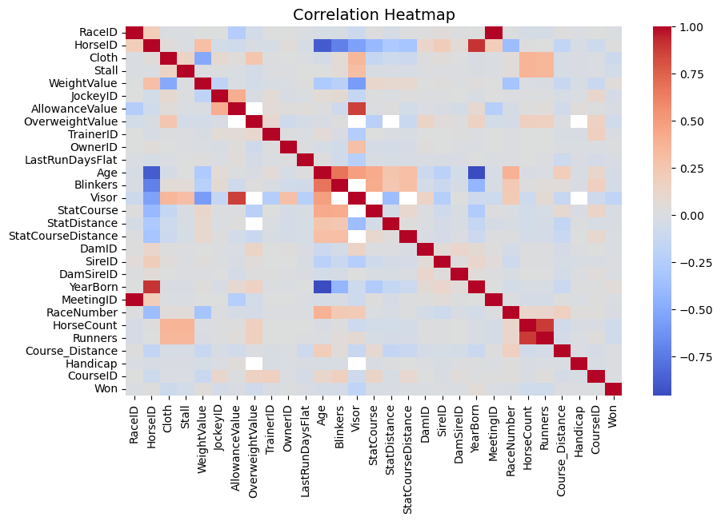

```python
#heatmap for numeric features to understand correlation of the variables with the win
plt.figure(figsize=(10, 6))
correlation = df_horse.corr()
sns.heatmap(correlation,annot=False, cmap='coolwarm', fmt='.2f', cbar=True)
plt.title('Correlation Heatmap', fontsize=14)
plt.show()
```

### Observation from correlation

- A few correlations exist between some of the numerical features
- No feature has a strong correlation with the target variable Won

# DATA VISUALIZATION

#### Pie Chart to determine the percentage mix of winnings and losses

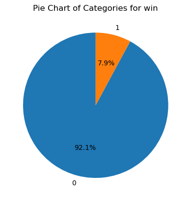

```python
won_pct = df_horse['Won'].value_counts() #returns a series with index of 0s and 1s along with their count

# Create pie chart
plt.pie(won_pct, labels=won_pct.index, autopct='%1.1f%%', startangle=90)
plt.title('Pie Chart of Categories for win')
plt.show()
```

only 8% of the data contains winnings. Note: The dataset is imbalanced, with more horses not winning (Won = 0) compared to those that did (Won = 1). Insight: in the event of predictive modelling or supervised learning classification, we might encounter challenges like Overfitting and low sensititivity to wins.

#### Box and whisker Plot to determine how the weight values

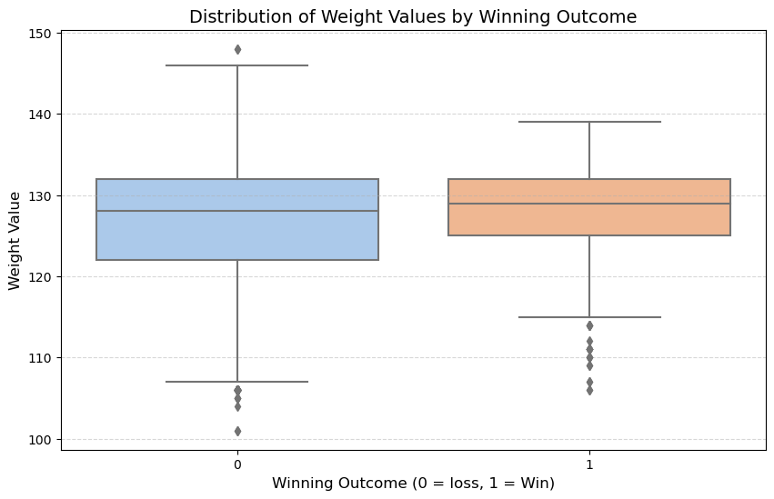

```python
plt.figure(figsize=(10, 6))
sns.boxplot(data=df_horse, x='Won', y='WeightValue', palette='pastel')

# Add title and labels
plt.title('Distribution of Weight Values by Winning Outcome', fontsize=14)
plt.xlabel('Winning Outcome (0 = loss, 1 = Win)', fontsize=12)
plt.ylabel('Weight Value', fontsize=12)
plt.grid(axis='y', linestyle='--', alpha=0.5)
plt.show()
```

### Observations

- From the boxplot, there is no significant difference between the median of the weight value for Win and loss.
- A narrower box for Won = 1 suggests more consistent weight values for winning horses as against the wider box for won=0 indicating variability in the weights of losing horses.
- significant overlap between the weightValue distribution for the win and loss might suggest that weight alone is not a strong predictor of winning
- More outliers exist for the wins than losses. Does this imply that horses with significantly light weight could still win?

### Time series to observe the trend of races against the number of races

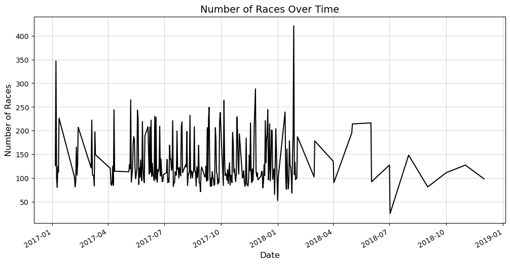

```python
#plotting a time series to understand the race trends with time

df_horse['MeetingDate'] = pd.to_datetime(df_horse['MeetingDate']) # changing the MeetingDate columnt to datetime datatype

# Group by date and count the number of races
races_over_time = df_horse.groupby('MeetingDate').size()

# Plot races over time
plt.figure(figsize=(12, 6))
races_over_time.plot(kind='line', color='black')
plt.title('Number of Races Over Time', fontsize=14)
plt.xlabel('Date', fontsize=12)
plt.ylabel('Number of Races', fontsize=12)
plt.grid(alpha=0.5)
plt.show()
```

### Observing features and how they could affect winning.

```python
df_horse_win = df_horse[df_horse['Won']==1] #filtering the dataframe for wins
df_horse_win.head()
```

|  | RaceID | HorseID | Cloth | Stall | WeightValue | JockeyID | AllowanceValue | OverweightValue | TrainerID | OwnerID | LastRunDaysFlat | Age | Blinkers | Visor | ForecastPrice | StatCourse | StatDistance | StatCourseDistance | StartingPrice | Bred | DamID | SireID | DamSireID | Sex | Colour | YearBorn | MeetingID | RaceNumber | HorseCount | … |
| --- | --- | --- | --- | --- | --- | --- | --- | --- | --- | --- | --- | --- | --- | --- | --- | --- | --- | --- | --- | --- | --- | --- | --- | --- | --- | --- | --- | --- | --- | --- |
| 3 | 989418 | 2960365 | 1 | 12.0 | 132 | 1417524.0 | NaN | NaN | 1049637 | 1487690.0 | 33.0 | 3.0 | NaN | NaN | 07-Apr | NaN | NaN | NaN | 11-Oct | SAF | 2347111.0 | 2170013.0 | 2071137.0 | f | b | NaN | 87048 | 1 | 13 | … |
| 25 | 989419 | 2946436 | 2 | 8.0 | 132 | 1168599.0 | NaN | NaN | 1288373 | 1397040.0 | 12.0 | 4.0 | 3.0 | NaN | 09-Feb | NaN | NaN | NaN | 17-Feb | SAF | 2791321.0 | 2618753.0 | 2064086.0 | g | b | NaN | 87048 | 2 | 13 | … |
| 27 | 989420 | 2930032 | 1 | 2.0 | 132 | 1138258.0 | NaN | NaN | 1138261 | 1471450.0 | 15.0 | 4.0 | 13.0 | NaN | 12-Jan | NaN | NaN | NaN | 13-Feb | SAF | 2621302.0 | 2271400.0 | 2170172.0 | f | ch | NaN | 87048 | 3 | 10 | … |
| 40 | 989421 | 2855420 | 2 | 4.0 | 131 | 1398052.0 | NaN | NaN | 1240064 | 1440857.0 | 12.0 | 6.0 | NaN | NaN | 07-Jan | NaN | 3.0 | 1.0 | 09-Feb | SAF | 2855419.0 | 2696814.0 | 2170209.0 | g | ch | 2011.0 | 87048 | 4 | 10 | … |
| 50 | 989422 | 2922526 | 2 | 8.0 | 131 | 1417524.0 | NaN | NaN | 1049637 | 1478935.0 | 15.0 | 4.0 | NaN | NaN | 02-Jan | 1.0 | 1.0 | NaN | 11-Aug | SAF | 2620754.0 | 2167985.0 | 2096866.0 | g | b | NaN | 87048 | 5 | 8 | … |

### How does WeightValue affect Winnings

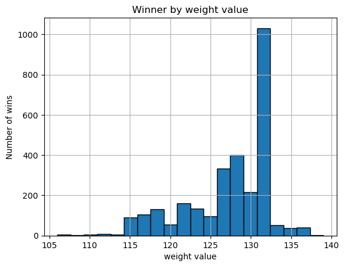

```python
df_horse_win['WeightValue'].hist(bins=20,edgecolor='Black')

#plot histogram of weightvalue against number of wins
plt.title('Winner by weight value')
plt.xlabel('weight value')
plt.ylabel('Number of wins')
```

### observations

- The data is left skewed or negatively skewed with the horses with higher weights contributing to the most wins.
- Horses with weight value of 132 had the most wins.

### How many races each horse has won.

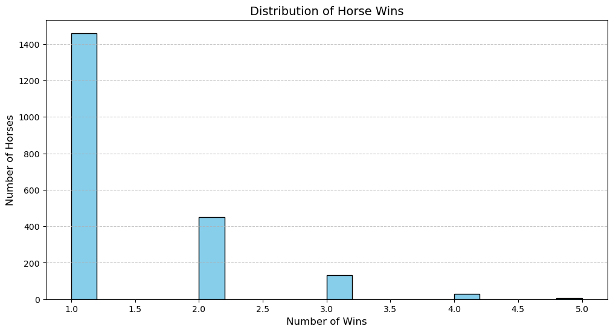

```python
# Group by 'HorseID' and count the number of wins
horse_wins = df_horse_win.groupby('HorseID').size().reset_index(name='WinCount') #reset_index() converts the series to Dataframe

# Plot a histogram of win counts
plt.figure(figsize=(12, 6))
plt.hist(horse_wins['WinCount'], bins=20, color='skyblue', edgecolor='black')
plt.title('Distribution of Horse Wins', fontsize=14)
plt.xlabel('Number of Wins', fontsize=12)
plt.ylabel('Number of Horses', fontsize=12)
plt.grid(axis='y', linestyle='--', alpha=0.7)
plt.show()
```

### Observations

- A significant number of horses(over 1400) won only once and only very few had consistently high wins.  
  can we infer from the data that the races are very competitive or the horses are having inconsistent performance?

### Investigating to what extent external factors affected or contributed to the horse winning.

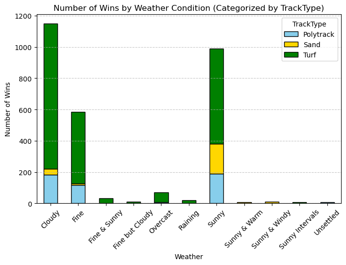

```python
# Count occurrences for Weather and Track Type
grouped_external_factors = df_horse_win.groupby(['Weather', 'TrackType']).size().unstack(fill_value=0)

# Plotting a bar chart
grouped_external_factors.plot(kind='bar', stacked=True, figsize=(8, 5), color=['skyblue', 'gold', 'green', 'orange'],edgecolor='black')

# Adding labels and title
plt.title('Number of Wins by Weather Condition (Categorized by TrackType)')
plt.xlabel('Weather')
plt.ylabel('Number of Wins')
plt.xticks(rotation=45)
plt.legend(title='TrackType')
plt.grid(axis='y', linestyle='--', alpha=0.7)
plt.show()
```

# SUMMARY AND QUESTIONS

1. Dataset consists of several missing values which brings the integrity of the data to question.
2. Wrong or unexpected values in ForecastPrice,StartingPrice ans ScheduledTime columns.
3. How would the above observation affect the overall analyses? This could be very important features that can aid our analysis.
4. Imbalance in Target column Won.There seems to be more losses than wins making the data not exactly suitable for predictive modelling.
5. From the dataset, success of a horse could be affected by external conditions like weather and Tracktype.
6. Why is it that only 2 years of this data was provided? would this be sufficient to make conclusive analyses on trends?
7. Horses seemed to have several sexes g,f,m,c,h. Could this be actually gender's for horses or error in input?

# CHALLENGES

1. Time constraints- The time allotted for this exercise was not sufficient for a more detailed analysis.
2. No domain knowledge on Horse racing. No data dictionary was provided to enable understanding of most of the features.